# Lignes, échelles et étiquettes

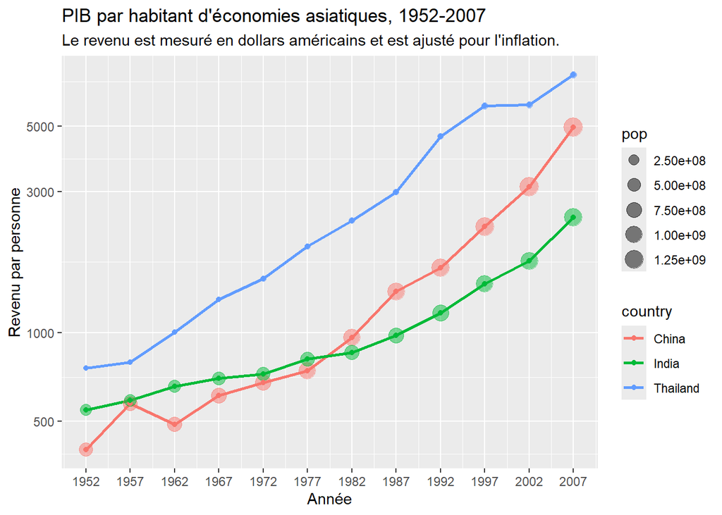

```r
ggplot(data = gap_mini2,
       mapping = aes(x = year,
                     y = gdpPercap,
                     color = country)) +
  geom_line(size = 1) +
  geom_point(mapping = aes(size = pop),
                           alpha = 0.5) +
  geom_point() +
  scale_x_continuous(breaks = gap_years) +
  scale_y_log10()  +
  labs(x = "Année",
       y = "Revenu par personne",
       title = "PIB par habitant d'économies asiatiques, 1952-2007",
       subtitle = "Le revenu est mesuré en dollars américains et est ajusté pour l'inflation.")
```

Le titre par défaut d’une légende est le nom de la variable à laquelle elle correspond. Ici, la légende de `color` est intitulée `country`, et la légende de `size` est intitulée `pop`.

Nous pouvons également les modifier dans `labs()` en définissant `NOM_AES = "NOUVEAU_TITRE"`.

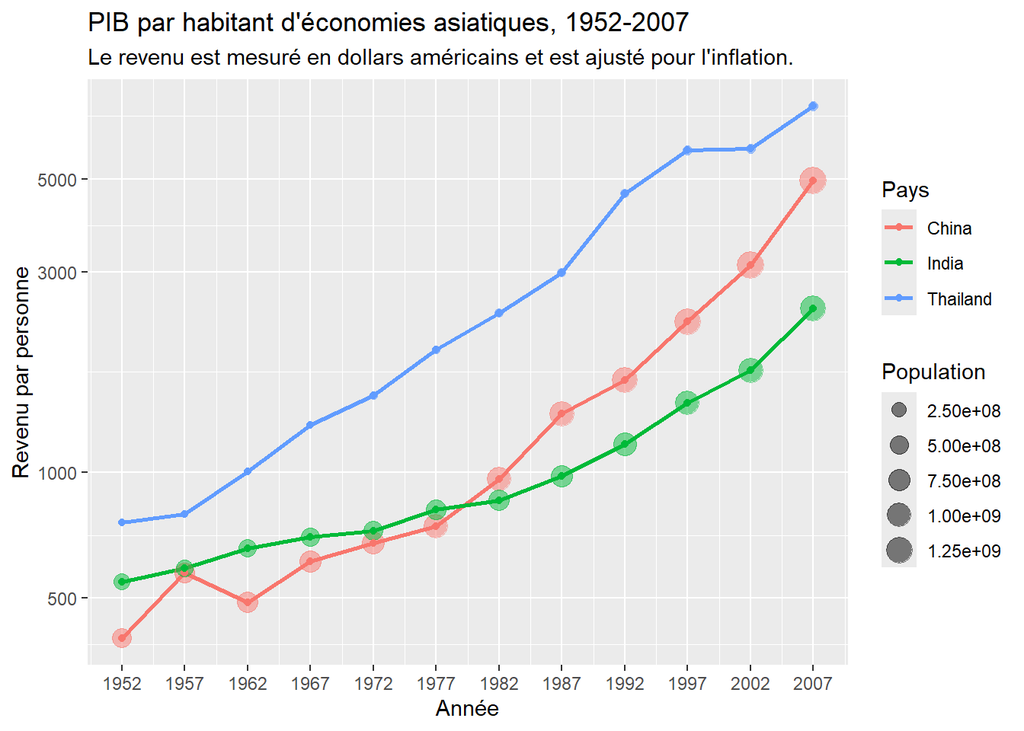

```r
ggplot(data = gap_mini2,
       mapping = aes(x = year,
                     y = gdpPercap,
                     color = country)) +
  geom_line(size = 1) +
  geom_point(mapping = aes(size = pop),
                           alpha = 0.5) +
  geom_point() +
  scale_x_continuous(breaks = gap_years) +
  scale_y_log10()  +
  labs(x = "Année",
       y = "Revenu par personne",
       title = "PIB par habitant d'économies asiatiques, 1952-2007",
       subtitle = "Le revenu est mesuré en dollars américains et est ajusté pour l'inflation.",
       color = "Pays",
       size = "Population")
```

La même syntaxe peut être utilisée pour modifier les titres des légendes des autres mappings esthétiques. Une erreur courante est d’utiliser le nom de la variable au lieu du nom de l’esthétique dans `labs()`, donc faites attention !

Créez un graphique de série temporelle comparant les tendances du PIB par habitant de 1952 à 2007 pour **trois pays** dans le dataframe `gapminder`.

Utilisez **`my_gap_mini`** pour créer un graphique avec les attributs suivants :

- Ajoutez des points au graphique linéaire
- Coloriez les lignes et les points par pays
- Augmentez l’épaisseur des lignes à 1mm et la taille des points à 2mm
- Rendez les lignes transparentes à 50%
- Changez les intervalles de l’échelle de l’axe des x pour correspondre aux années dans le jeu de données

Enfin, ajoutez les étiquettes suivantes à votre graphique :

- Titre : “Santé & richesse des nations”
- Titres d’axes : “Longévité” et “Année”
- Titre de la légende : “Pays”

```r
# Écrivez le code pour créer votre graphique :
q8 <- "ÉCRIVEZ_VOTRE_CODE_ICI"

# Vérifiez votre réponse
.CHECK_q8()
```

```
## Incorrect. Votre résultat devrait être un objet ggplot2. Veuillez réessayer.
##   1   2   3   4   5   6   7  ᐅ8ᐊ
```

```r
.HINT_q8()
```

```
##
## Assurez-vous de ne pas ajouter de modifications supplémentaires que la question n'a pas demandées, sinon la fonction CHECK le considérera comme incorrect.
```

# 10 Preview : Les thèmes

Dans le prochain cours, nous allons apprendre à utiliser les fonctions `theme`.

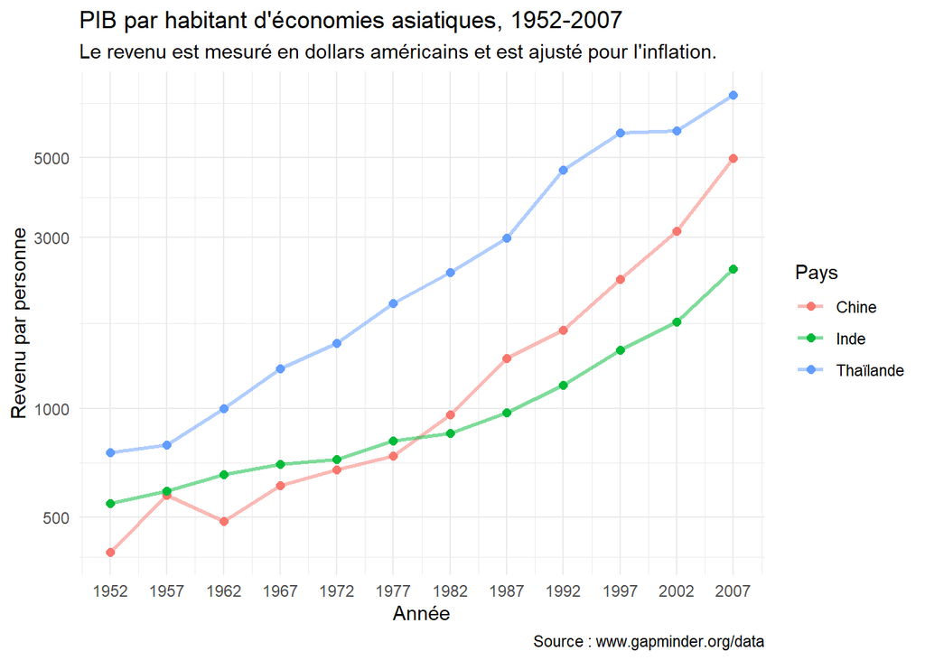

```r
# Utiliser theme_minimal()
ggplot(data = gap_mini2,
       mapping = aes(x = year,
                     y = gdpPercap,
                     color = country)) +
  geom_line(size = 1, alpha = 0.5) +
  geom_point(size = 2) +
  scale_x_continuous(breaks = gap_years) +
  scale_y_log10() +
  labs(x = "Année",
       y = "Revenu par personne",
       title = "PIB par habitant d'économies asiatiques, 1952-2007",
       subtitle = "Le revenu est mesuré en dollars américains et est ajusté pour l'inflation.",
       caption = "Source : www.gapminder.org/data",
       color = "Pays") +
  scale_color_discrete(labels = c("China" = "Chine", "India" = "Inde", "Thailand" = "Thaïlande")) +
  theme_minimal()
```

# 11 En résumé

Les graphiques linéaires, à l’instar des graphiques de dispersion, sont des outils efficaces pour représenter la relation entre deux variables numériques. Lorsque l’une de ces variables est temporelle, l’usage d’un graphique linéaire est plus adapté. De ce fait, il est conseillé d’opter pour des graphiques linéaires plutôt que des graphiques de dispersion lorsque la variable sur l’axe des abscisses (c’est-à-dire, la variable explicative) possède un ordre intrinsèque, comme c’est le cas pour une variable temporelle telle que `year` dans le dataframe `gapminder`.

Il est possible de transformer les échelles et de modifier les graduations des axes afin de rendre nos graphiques plus lisibles. De plus, l’ajout d’étiquettes permet d’incorporer davantage d’informations.

J’espère que vous avez trouvé ce cours instructif !

# Contributeurs

Les membres suivants ont contribué à ce cours :

- [JOY VAZ](https://thegraphcourses.org/members/joy)  
  R Developer and Instructor, the GRAPH Network

  Loves doing science and teaching science
- [IMANE BENSOUDA KORACHI](https://thegraphcourses.org/members/imane/)  
  R Developer and Instructor, the GRAPH Network
- [ADMIN TEAM](https://thegraphnetwork.training/members/admin/)  
  GRAPH Courses Administration Team

  The GRAPH Courses team is building epidemiological training courses to enhance disease surveillance and data science for public health across the globe

# Références

Le contenu de ce cours a été adapté en partie des sources suivantes :

- Ismay, Chester, and Albert Y. Kim. 2022. *A ModernDive into R and the Tidyverse*. https://moderndive.com/.
- Kabacoff, Rob. 2020. *Data Visualization with R*. https://rkabacoff.github.io/datavis/.
- https://www.rebeccabarter.com/blog/2017-11-17-ggplot2_tutorial/

This work is licensed under the [Creative Commons Attribution Share Alike](https://creativecommons.org/licenses/by-sa/4.0/) license.